# Insect Behavior

From: [World Crop Pests, 1997](https://www.sciencedirect.com/science/article/pii/S1572437997800826)

## Related terms:

- [Host Plant](https://www.sciencedirect.com/topics/agricultural-and-biological-sciences/host-plant)
- [Pheromone](https://www.sciencedirect.com/topics/agricultural-and-biological-sciences/pheromone)
- [Aphid](https://www.sciencedirect.com/topics/agricultural-and-biological-sciences/aphid)
- [Drosophila](https://www.sciencedirect.com/topics/agricultural-and-biological-sciences/drosophila)
- [Herbivore](https://www.sciencedirect.com/topics/agricultural-and-biological-sciences/herbivore)
- [Coleoptera](https://www.sciencedirect.com/topics/agricultural-and-biological-sciences/coleoptera)
- [Bee](https://www.sciencedirect.com/topics/agricultural-and-biological-sciences/bee)

[View all Topics](https://www.sciencedirect.com/topics)

## [Molecular Genetics of Insect Behavior](https://www.sciencedirect.com/science/article/pii/B978012815230000011X)

Marjorie A. Hoy, in [Insect Molecular Genetics (Fourth Edition)](https://www.sciencedirect.com/book/9780128152300/insect-molecular-genetics), 2019

### 11.2 Introduction

Insect behavior covers a very wide range of activities, including locomotion, grooming, feeding, communication, reproduction, dispersal, flight, learning, migration, host or prey selection, diapause, and various responses to environmental hazards such as temperature, humidity, parasites, and toxins (Beck, 1980; Alcock, 1984; Tauber et al., 1986; Gatehouse, 1997; Bazzett, 2008; Ikeno et al., 2011). Understanding the behavior of pest and beneficial insects could improve pest-management programs (Renou and Guerrero, 2000; Bendena, 2010).

One definition of **behavior** is any action that an individual carries out in response to a stimulus or its environment, especially an action that can be observed and described. However, insects also behave spontaneously, in the absence of any obvious stimulus. Thus, behavior includes studies to understand how an insect takes in information from its environment, processes that information, and acts. Processing information in the [central nervous system](https://www.sciencedirect.com/topics/agricultural-and-biological-sciences/central-nervous-system) may involve integrating information over time, including stimuli such as hormones coming from within the insect. Thus, the connection between **stimulus** and **response** can be delayed and indirect.

The genetic analysis of behavior rightfully has been perceived to be more complex than analysis of morphological or anatomical traits (Vanin et al., 2012). One complication in genetic analyses of behavior is the difficulty in defining the behavior in a clear manner. Often “a behavior” may consist of multiple components, which can lead to confusion regarding the number of genes involved. Distinguishing between behavior and physiology can be particularly difficult. The same behavior can be examined from at least four different viewpoints: (1) the immediate cause (or control); (2) its development during the individual’s lifespan; (3) the function of the behavior; and (4) how the behavior evolved (Wyatt, 1997).

Behavior genetics began to develop as a field of study in the 1960s, but was limited to demonstrating that a behavioral trait was heritable, determining whether its **mode of inheritance** was dominant or recessive, sex-linked or autosomal, and resolving whether the variation was due to single or multiple genes. Genetic analyses of insect behavior require careful control of environmental conditions, because even subtle differences in test conditions can influence results of assays (Vanin et al., 2012). Objective measures of insect behavior are difficult, and considerable efforts have been devoted to devising specific and appropriate assays. The possible influence of learning always must be considered and, to complicate matters further, learning rates vary among populations of the same species and among individuals so both heredity and environment must be considered. Furthermore, recent studies indicate individuals have “personalities”; for example, some may be more adventurous than others. Genetic analyses of insect behavior involve, in many cases, analyses of the physiological or morphological changes associated with the change in behavior. Sometimes, however, behavior is changed in an insect because a morphological trait has been altered through mutation.

The genetic basis of insect behavior initially was analyzed most extensively using *Drosophila* *melanogaster* and [honey bees](https://www.sciencedirect.com/topics/agricultural-and-biological-sciences/honey-bees), grasshoppers, *[Nasonia](https://www.sciencedirect.com/topics/agricultural-and-biological-sciences/nasonia)* parasitoids, and crickets. Now, [molecular genetic](https://www.sciencedirect.com/topics/agricultural-and-biological-sciences/molecular-genetics) techniques provide powerful methods to analyze olfaction, learning, circadian rhythms, and mating behavior in many species. Having the complete genomes insects simplifies the isolation of specific genes involved in behavior. *P*-element-mediated transformation makes it possible to insert genes from one species of *Drosophila* into the genome of another to determine their effect(s).

[Molecular genetic](https://www.sciencedirect.com/topics/agricultural-and-biological-sciences/molecular-genetics) analyses of learning and memory in *Drosophila* provided a means to study one of the most challenging frontiers in neurobiology (Waddell and Quinn, 2001). Molecular genetics may allow us to localize and identify some of the individual genes among the “many” involved in interesting and complex behaviors exhibited by insects (Doerge, 2002). Perhaps the most significant advance in the study of behavior has been the sequencing of genomes of insects other than *Drosophila*. This has allowed novel and detailed studies in a variety of insects and promises to provide exceptional new insights.

Analyses of insect behavior employ techniques from several disciplines including anatomy, biochemistry, ecology, **ethology** (study of animal behavior in the natural environment), genetics, psychology, physiology, and statistics (Matthews and Matthews, 1978; Hay, 1985; Bell, 1990; Via, 1990; Barton Browne, 1993; Heisenberg, 1997; Doerge, 2002). These disciplines are required because an insect perceives the environment through its [sensory systems](https://www.sciencedirect.com/topics/agricultural-and-biological-sciences/sensory-system). The external sensory stimuli are transduced into electrical information, which is then processed and decoded, leading to a behavioral response. Behavior can be divided into several sequential steps: **stimulus recognition**, [signal transduction](https://www.sciencedirect.com/topics/agricultural-and-biological-sciences/signal-transduction), **integration**, and **response** or motor output.

[View chapter](https://www.sciencedirect.com/science/article/pii/B978012815230000011X)[Purchase book](https://www.elsevier.com/books/T/A/9780128152300)

## [Stored-Product Insect Behavior](https://www.sciencedirect.com/science/article/pii/B978189112746550012X)

James F. Campbell, in [Insect Management for Food Storage and Processing (Second Edition)](https://www.sciencedirect.com/book/9781891127465/insect-management-for-food-storage-and-processing), 2006

### CONCLUSIONS

Understanding insect behavior is critical for successfully managing stored-product insect pests, particularly in the current climate where more-targeted IPM programs are becoming more widely used. IPM relies on a fundamental understanding of pest behavior and its implications for ecological parameters such as spatial distribution and population dynamics. This chapter has illustrated some of the advances in our understanding of stored-product insect behavior and how it can be applied to management. Many questions still remain and many pest species are not well understood. I have emphasized the broader concepts that will help in understanding how stored-product insects perceive and interact with the world around them. I hope this will help with the development, implementation, and evaluation of pest-monitoring and management programs.

[View chapter](https://www.sciencedirect.com/science/article/pii/B978189112746550012X)[Purchase book](https://www.elsevier.com/books/T/A/9781891127465)

## [Fungal Entomopathogens](https://www.sciencedirect.com/science/article/pii/B9780123849847000063)

Fernando E. Vega, ... Meredith Blackwell, in [Insect Pathology (Second Edition)](https://www.sciencedirect.com/book/9780123849847/insect-pathology), 2012

### Insect Responses to Infection

Insect behavior can alter the success of fungal [entomopathogen](https://www.sciencedirect.com/topics/agricultural-and-biological-sciences/entomopathogens) infection. In theory, social insects are at greater risk of infection by pathogens because many individuals live close together and are often closely related. However, social insects have evolved a range of mechanisms to defend against pathogens (Cremer *et al.*, 2007). For example, termites (Boucias *et al.*, 1996; Rosengaus *et al.*, 1998; Yanagawa *et al.*, 2008) and ants (Kermarrec *et al.*, 1986; Jaccoud *et al.*, 1999) exhibit mutual grooming behavior to remove [conidia](https://www.sciencedirect.com/topics/agricultural-and-biological-sciences/conidium) from themselves and from colony members. Furthermore, the metapleural glands of ants produce antibiotic secretions that inactivate fungal entomopathogens (Hughes *et al.*, 2002; Yek and Mueller, 2011). Cremer *et al.* (2007) list a range of mechanisms by which social insects can combat pathogen establishment. Nielsen *et al.* (2010) showed that aphid-tending ants remove sporulating aphid corpses infected with *P. neoaphidis* and will also groom aphids and remove conidia from the aphid cuticle, possibly to protect their mutualistic honeydew-producing resource.

Some non-social insects have been shown to exhibit density-dependent prophylaxis, i.e., increased resistance to pathogens when reared under high-density conditions (Wilson and Reeson, 1998). *[Spodoptera littoralis](https://www.sciencedirect.com/topics/agricultural-and-biological-sciences/spodoptera-littoralis)* (Wilson *et al.*, 2001) and *[Tenebrio molitor](https://www.sciencedirect.com/topics/agricultural-and-biological-sciences/tenebrio-molitor)* (Barnes and Siva-Jothy, 2010) have shown increased resistance to *B. bassiana* and *M. anisopliae*, respectively, when reared in crowded conditions. This increased resistance appears to be related to cuticular melanization, i.e., the formation of the pigment melanin by polymerization of phenolic compounds (Charnley, 1984; Jacobson, 2000). In contrast, the increased resistance against *M. acridum* in *S. gregaria* reared in crowded conditions appears to be related to increased antimicrobial activity (Wilson *et al.*, 2002),

Once the fungal entomopathogen reaches the hemolymph, a range of immune responses can be initiated (see Chapter 13). Some are general antimicrobial responses while some are specifically targeting the invading fungus (see Rolff and Reynolds, 2009, for reviews of insect immune mechanisms, including evolutionary and ecological implications). Fungal units can be cellularly phagocytosed or encapsulated (Charnley, 1984; Gillespie *et al.*, 1997). *[Metarhizium anisopliae](https://www.sciencedirect.com/topics/agricultural-and-biological-sciences/metarhizium-anisopliae)* and *B. bassiana* are capable of avoiding encapsulation in the hemocoel, and this adaptation has been hypothesized to be a consequence of these fungi being facultative entomopathogens in soil environments where they can survive encapsulation by soil amoeboid predators (Bidochka *et al.*, 2010). A fascinating response to fungal infections is the concept of behavioral fever (Roy *et al.*, 2006), whereby infected insects (e.g., locusts, flies) modify their behavior (e.g., basking in the sun) to increase body temperature, with an adverse effect on the fungal entomopathogen present in the hemocoel (Carruthers *et al.*, 1992; Kalsbeek *et al.*, 2001; Elliot *et al.*, 2002).

[View chapter](https://www.sciencedirect.com/science/article/pii/B9780123849847000063)[Purchase book](https://www.elsevier.com/books/T/A/9780123849847)

## [Resource Acquisition](https://www.sciencedirect.com/science/article/pii/B9780120887729500261)

Timothy D. Schowalter, in [Insect Ecology (Second Edition)](https://www.sciencedirect.com/book/9780120887729/insect-ecology), 2006

### A Foraging strategies

Insect behavior can be viewed from the standpoint of efficiency of resource acquisition and allocation (Sterner and Elser 2002, see also Chapter 4). Foraging should focus on resources that provide the best return and minimum risk for the effort expended. Hence, bumble bees, *[Bombus](https://www.sciencedirect.com/topics/agricultural-and-biological-sciences/bombus)* spp., forage on low-energy resources only at high temperatures when the insects do not require large amounts of energy to maintain sufficiently high body temperature for flight (Bell 1990, Heinrich 1979, 1993). Other host-seeking insects tend to focus their searching where the probability of host discovery is highest (i.e., where hosts are concentrated or most apparent) (Bell 1990, Kareiva 1983).

Foraging theory focuses on optimization of diet, risk, and [foraging efficiency](https://www.sciencedirect.com/topics/earth-and-planetary-sciences/foraging-efficiency) (Kamil *et al*. 1987, Schultz 1983, Stephens and Krebs 1986, Townsend and Hughes 1981). Profitable resources provide a gain to the consumer, but nonnutritive or toxic resources represent a cost in terms of time, energy, or nutrient resources expended in detoxification or continued search. Continued search also increases exposure to predators or other mortality agents. Sublethal doses of defensive chemicals reduce nutritional value of the resource, so they should be avoided when resources are abundant but they may be eaten when more profitable resources are unavailable or not apparent (Courtney 1985, 1986). Consumers should maximize foraging efficiency by focusing on patches with high profitability (and ignore low-profitability patches) until their resource value declines below the average for the landscape matrix. Orientation toward cues indicating suitable resources improves the efficiency of food acquisition. Furthermore, learning confers an ability to improve resource acquisition as a result of experience.

Most insects must search for suitable food at some spatial scale. Even within a particular plant, nutritional quality may vary considerably among individual leaves (e.g., between sun and shade leaves, young and old leaves) (Schultz 1983, Whitham 1983). Foraging strategy represents a tradeoff between costs (in terms of reduced growth and survival) of searching, costs of feeding on less suitable food, and costs of exposure to predators.

Schultz (1983) developed a tradeoff surface to illustrate four foraging strategies for arboreal caterpillars (Fig. 3.11). Foraging can be optimized by searching for more nutritive food and risking attention of predators, accepting less nutritive food, or defending against predation. Natural selection can favor a reduction in cost along any of the three axes, within constraints of the other two costs. Feeding selectively on the most suitable food during the day incurs a moderate cost of movement (energy expenditure at higher temperature) and high risk of predation. Selective feeding at night reduces [predation risk](https://www.sciencedirect.com/topics/earth-and-planetary-sciences/predation-risk) but increases the energetic cost of movement under cooler temperatures, which then restricts the time spent feeding, especially at [high latitudes](https://www.sciencedirect.com/topics/earth-and-planetary-sciences/polar-region). [Crypsis](https://www.sciencedirect.com/topics/agricultural-and-biological-sciences/crypsis) (camouflage) reduces the risk of predation for day-feeders, but the cost of movement (in terms of attraction of predators) is substantial and limits ability to search for the most suitable food. Conversely, apo-somatic (warning) coloration can reduce the risk of predation and allow greater freedom of movement, but the energy expenditure of movement and cost of biochemical sequestration must be considered. Species that mimic, and live on or in, their food can avoid both movement and predation costs but have no choice in their food after initial colonization. Hence, feeding costs may be quite high.

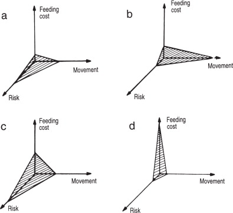

Fig. 3.11. Tradeoff planes of selected caterpillar foraging strategies. Costs of feeding (i.e., metabolic costs of digestion, reduced growth, etc.), movement (metabolic costs of reduced growth), and risks (e.g., probability of capture or reduced growth as a result of time spent hiding) increase in the direction of the arrows: **a:** selective diurnal feeder, **b:** selective nocturnal aposomatic feeder, **c:** diurnal cryptic feeder, and **d:** food mimic. From Schultz (1983). Please see extended permission list pg 569.

Predators also face [tradeoffs](https://www.sciencedirect.com/topics/earth-and-planetary-sciences/tradeoff) between hunting, ambush, or intermediate strategies. Hunting requires considerable expenditure of energy searching for prey, but it has a high return, depending on ability to detect prey from a distance. Detection can be increased by orienting toward prey odors or plant odors indicative of prey. Accordingly, many predaceous species are attracted to mating pheromones of their prey (Stephen *et al*. 1993) or to volatile chemicals released by plants in response to herbivory (Turlings *et al*. 1993). Ambushers either sit and wait or use traps to [capture prey](https://www.sciencedirect.com/topics/earth-and-planetary-sciences/prey-capture). As examples, dragonfly larvae hide in the substrate of [aquatic habitats](https://www.sciencedirect.com/topics/agricultural-and-biological-sciences/aquatic-habitat) and grasp prey coming within reach, antlion larvae excavate conical depressions in loose [sandy soil](https://www.sciencedirect.com/topics/agricultural-and-biological-sciences/sandy-soils) that prevents escape of ants and other insects that wander into the pit, and webspinning spiders construct sticky orb or tangled webs that trap flying or crawling insects. Movement costs are minimal for these species, but prey encounter is uncertain. Frequency of prey encounter can be increased by selecting sites along prey foraging trails, near prey nest sites, etc.

[View chapter](https://www.sciencedirect.com/science/article/pii/B9780120887729500261)[Purchase book](https://www.elsevier.com/books/T/A/9780120887729)

## [Molecular and Neural Control of Insect Circadian Rhythms](https://www.sciencedirect.com/science/article/pii/B9780123847478100157)

Yong Zhang, Patrick Emery, in [Insect Molecular Biology and Biochemistry](https://www.sciencedirect.com/book/9780123847478/insect-molecular-biology-and-biochemistry), 2012

### 15.1.2 Circadian Behavioral Rhythms

Many insect behaviors are under circadian regulation. Locomotor activity is the most intensively studied circadian behavior in insects (see, for example, Konopka and Benzer, 1971; Saunders and Thomson, 1977; Kenny and Saunders, 1991; Page, 1982; Fleury *et al.*, 1995; Cymborowski *et al.*, 1996; Clark *et al.*, 1997). *Drosophila* *melanogaster*, for example, shows two peaks of locomotor activity around dawn and dusk, which are frequently called morning and evening peaks, respectively (**Figure 1**). These two peaks persist under constant darkness and constant temperature, and are thus circadian, although the morning peak tends to progressively weaken, for unclear reasons. We will discuss in detail the neural bases for these two peaks in section 15.4, and the molecular mechanisms underlying these rhythms in section 15.2.

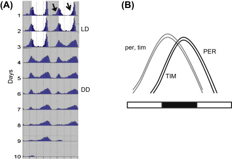

Figure 1. *Drosophila* circadian locomotor behavior and gene expression. (A) Actogram showing the average locomotor activity of a group of *Drosophila* males. Individual flies are placed in small glass tubes with sugar food and monitored under a 12 : 12 light : dark (LD) cycle for 3 days, and then released in constant darkness (DD). Gray shading indicates the dark phase of LD or DD. The actogram is double-plotted: each day (except the first) is plotted twice, first on the right half of the actogram, and then on the left half on the next line. Full and empty arrows indicate the morning and evening peaks of activity, respectively, which are controlled by the circadian clock. Zeitgeber Time (ZT) 0 corresponds to the beginning of the light phase. (B) Schematic representation of the expression pattern of two key circadian genes (*per* and *tim*) and their protein products. Gray lines represent mRNA levels, and black lines protein levels. The white and black bars indicate day and night, respectively.

Another well-studied insect circadian behavior is feeding (Abraham and Muraleedharan, 1990; Khan *et al.*, 1997; Sothern *et al.*, 1998; Das and Dimopoulos, 2008; Xu *et al.*, 2008). Among feeding rhythms, blood-sucking might be the first that comes to mind. Indeed, female mosquitoes bite us preferentially at certain times of the day, and are vectors of devastating diseases (malaria and Dengue fever, for example). These rhythmic biting activities have long been reported for various mosquitoes (see, for example, Haddow, 1956; Standfast, 1967), and were more recently proven to be controlled by circadian clocks (Pandian, 1994; Das and Dimopoulos, 2008). Related to feeding behavior, [foraging behavior](https://www.sciencedirect.com/topics/agricultural-and-biological-sciences/foraging-behavior) can also be circadianly controlled – for example, in honeybees and bumblebees (Moore *et al.*, 1989; Bloch, 2010; Stelzer *et al.*, 2010).

Circadian clocks also influence reproduction. Timing of mating behavior might even contribute to [reproductive isolation](https://www.sciencedirect.com/topics/agricultural-and-biological-sciences/reproductive-isolation), since closely related *Drosophila* species prefer to mate at different times (Sakai and Ishida, 2001a, 2001b). In *[Drosophila melanogaster](https://www.sciencedirect.com/topics/agricultural-and-biological-sciences/drosophila-melanogaster)*, male courtship is more frequent during the night and seems to drive rhythmic mating behavior (Fujii *et al.*, 2007), although earlier studies indicate that the female circadian clock also affects mating rhythms (Sakai and Ishida, 2001a). Mating rhythms are also found in cockroaches and moths, for example (Silvegren *et al.*, 2005; Rymer *et al.*, 2007). Interestingly, the production and release of, and response to, [sex pheromones](https://www.sciencedirect.com/topics/agricultural-and-biological-sciences/sex-pheromone) can be regulated by the circadian clock (Silvegren *et al.*, 2005; Merlin *et al.*, 2007; Krupp *et al.*, 2008). Another well-characterized circadian reproductive behavior is oviposition (egg-laying rhythms; for review, see Howlader and Sharma, 2006). Interestingly, the neural substrate regulating oviposition rhythms in *Drosophila melanogaster* is distinct from those controlling circadian eclosion (see below) and adult locomotor rhythms (Howlader *et al.*, 2006).

After egg-laying, important behaviors related to the transition from one developmental stage to another can be driven by the circadian clock. For instance, egg hatching is gated by the circadian clock in many insects (see, for example, Minis and Pittendrigh, 1968; Lazzari, 1991; Sauman and Reppert, 1996). Metamorphosis is also frequently circadian. During insect metamorphosis, ecdysteroid hormones are synthesized by the [prothoracic gland](https://www.sciencedirect.com/topics/agricultural-and-biological-sciences/prothoracic-gland) and released into the hemolymph to trigger adult ecdysis. The [prothoracicotropic hormone](https://www.sciencedirect.com/topics/agricultural-and-biological-sciences/prothoracicotropic-hormone) (PTTH) plays an important role in this process by stimulating the prothoracic gland. Circadian control of PTTH release, PTTH responsiveness, ecdysteroid synthesis, hemolymph ecdysteroid titer, and [ecdysteroid receptor](https://www.sciencedirect.com/topics/agricultural-and-biological-sciences/ecdysteroid-receptor) expression have been described in *[Rhodnius prolixus](https://www.sciencedirect.com/topics/agricultural-and-biological-sciences/rhodnius-prolixus)* and other insects (Cymborowski *et al.*, 1991; Vafopoulou and Steel, 1991, 1996; Pelc and Steel, 1997; Richter, 2001; for review, see Steel and Vafopoulou, 2006). Interestingly, in *Drosophila* the prothoracic gland shows rhythmic autonomous expressions of clock proteins (Emery *et al.*, 1997). *Drosophila* eclosion occurs preferentially around dawn, and this eclosion rhythm is absent in classic clock gene mutants (Konopka and Benzer, 1971; Sehgal *et al.*, 1994). *Drosophila* eclosion rhythms require both brain pacemaker neurons (the pigment dispersing factor (PDF) positive ventral lateral neurons – see section 15.4) and a functional clock in the prothoracic gland (Myers *et al.*, 2003).

Another behavior that is modulated by the circadian clock in *Drosophila* is larval photophobicity (Mazzoni *et al.*, 2005). *Drosophila* larvae (all stages except for late third-instar larvae) prefer to avoid exposure to light if possible. The clock modulates the photosensitivity of this behavior: larvae are more sensitive to light in the early morning.

Sophisticated behaviors such as time-compensated sun compass navigation require the circadian clock to correct the direction of flight as a function of time, because the position of the sun changes during the course of the day. This plays an essential role in long-distance foraging and migratory behavior – for example, in bees (Lindauer, 1960; Bloch, 2010) and Monarch butterflies (Mouritsen and Frost, 2002; Froy *et al.*, 2003; Reppert *et al.*, 2010). Strikingly, the waggle dance performed by forager honeybees to indicate the location of food to other foragers is also time-compensated to correct for changes in the solar azimuth (Lindauer, 1954).

[View chapter](https://www.sciencedirect.com/science/article/pii/B9780123847478100157)[Purchase book](https://www.elsevier.com/books/T/A/9780123847478)

## [Volume 3](https://www.sciencedirect.com/science/article/pii/B9780128096338012516)

Andre J. Riveros, Robert B. Srygley, in [Encyclopedia of Animal Behavior (Second Edition)](https://www.sciencedirect.com/referencework/9780128132524/encyclopedia-of-animal-behavior), 2019

### Tropotactic-Based Navigation

In tropotactic behavior, insects move toward or away from a stimulus, such as light, humidity, or temperature. Such movements typically lead the animals to more favorable conditions within relatively short distances. In cases where the directional stimulus and the magnetic field are spatially associated, an animal may substitute use of the latter as a directional cue if the primary stimulus is absent or lacks directional information.

For example, fruit fly (*D.* *melanogaster*: Diptera) larvae exhibit negative phototaxis during their first three developmental [instars](https://www.sciencedirect.com/topics/agricultural-and-biological-sciences/instar), but when they begin to search for a pupation site, they switch to positive phototaxis. In the right experimental setup, the light’s direction can be associated with the direction of the magnetic field. After experimental shifts of the field, fruit fly larvae reorient as predicted (Gegear *et al*., 2008).

As another example, mealworms (*[Tenebrio](https://www.sciencedirect.com/topics/biochemistry-genetics-and-molecular-biology/tenebrio)* *molitor*: Coleoptera) show positive phototaxis in low or high relative humidity, and negative phototaxis in intermediate conditions. Similar to fruit flies, the light’s direction can be associated with the direction of the magnetic field. This has been verified by shifting the magnetic field under homogeneous lighting or in the absence of light (Vácha and Soukopová, 2004). Under homogeneous light conditions, adult mealworms moved toward the predicted direction of greater or lesser light that was indicated by the rotated magnetic field, whereas they oriented randomly in darkness.

[View chapter](https://www.sciencedirect.com/science/article/pii/B9780128096338012516)[Purchase book](https://www.elsevier.com/books/T/A/9780128132524)

## [Culture and Colonization](https://www.sciencedirect.com/science/article/pii/B9780122573057500540)

L.K. ETZEL, E.F. LEGNER, in [Handbook of Biological Control](https://www.sciencedirect.com/book/9780122573057/handbook-of-biological-control), 1999

### Behavior

Knowledge of insect behavior is obviously crucial to designing a successful rearing program. This is evident in devising an ovipositional substrate and stimulus. Blenk *et al.* (1985) discovered that six of seven reared noctuid species would oviposit on the underside of a paper towel on top of an oviposition cage, whereas the black [cutworm](https://www.sciencedirect.com/topics/agricultural-and-biological-sciences/cutworms), *[Agrotis ipsilon](https://www.sciencedirect.com/topics/agricultural-and-biological-sciences/agrotis-ipsilon)* (Hufnagel), would only oviposit on paper toweling in the bottom of the unit. On the other hand, Guthrie *et al.* (1985) observed that [European corn borer](https://www.sciencedirect.com/topics/agricultural-and-biological-sciences/european-corn-borer) moths would oviposit only on smooth surfaces; and Hartley (1990) reported that polyester–cotton cloth used for oviposition by *[Heliothis](https://www.sciencedirect.com/topics/agricultural-and-biological-sciences/heliothis)* spp. had to be replaced by a polyester-cotton cloth with a dimpled surface for oviposition by the beet armyworm, the [velvetbean](https://www.sciencedirect.com/topics/agricultural-and-biological-sciences/mucuna-pruriens) caterpillar, and the soybean looper, *[Pseudoplusia includens](https://www.sciencedirect.com/topics/agricultural-and-biological-sciences/pseudoplusia-includens)* (Walker).

Chemical ovipositional stimuli may also be necessary. Adult seed corn maggots oviposit in response to moist soil, decaying vegetation, germinating seeds, and metabolites produced by seed-borne [microorganisms](https://www.sciencedirect.com/topics/earth-and-planetary-sciences/micro-organism) (Whistlecraft *et al.,* 1985a). Likewise, rearing of the biological control agent *Weiseana barkeri* Jacoby, a chrysomelid that feeds on *[Acacia](https://www.sciencedirect.com/topics/agricultural-and-biological-sciences/acacia)* *nilotica,* requires the use of A. *nilotica* foliage to stimulate oviposition into strips of corrugated cardboard (Marohasy, 1994). On the other hand, insect-produced chemicals may deter oviposition. Boller (1985) found that the European [cherry](https://www.sciencedirect.com/topics/agricultural-and-biological-sciences/cherries) fruit fly and the [Mediterranean fruit fly](https://www.sciencedirect.com/topics/agricultural-and-biological-sciences/ceratitis-capitata) produced oviposition-deterring pheromones that lowered egg deposition in artificial devices. Consequently, the devices needed frequent washing.

Insect responses to stimuli can simplify rearing. For example, the positive phototaxis of scale crawlers makes them easily collected. Papacek and Smith (1985) lighted a rearing room for oleander scale 2 h before work began so scale crawlers would accumulate on top of butternut pumpkins. Such positive phototaxis is a common attribute of many insects and is similarly useful in their collection.

In some cases the combining of behavioral characteristics may be disadvantageous. Grisdale (1985a) reported that first-instar hemlock loopers are strongly photopositive and active, but also cannibalistic. Because the larvae drink readily, a light spray of distilled water and retention in the dark at 18°C reduce cannibalism.

Light can also affect insect emergence. Willey (1985) noted that range grasshopper nymphs hatch from eggs daily about 5 to 8 h after the start of the light cycle, so daily collection is timed accordingly. Similarly, Boller (1985) observed that the European cherry fruit fly and the Mediterranean fruit fly both emerge mostly during the morning and oviposit in the afternoon.

[View chapter](https://www.sciencedirect.com/science/article/pii/B9780122573057500540)[Purchase book](https://www.elsevier.com/books/T/A/9780122573057)

## [Principles](https://www.sciencedirect.com/science/article/pii/B9780124262607500057)

Jack R. Plimmer, in [Handbook of Pesticide Toxicology (Second Edition)](https://www.sciencedirect.com/book/9780124262607/handbook-of-pesticide-toxicology), 2001

### 2.4.1.6 Compounds That Affect Insect Behavior

A variety of compounds affect insect behavior. Repellents, such as DEET (*N, N*-diethyltoluamide) are applied directly to the skin. A variety of synthetic compounds, extracts, and baits are used in [insect traps](https://www.sciencedirect.com/topics/agricultural-and-biological-sciences/insect-traps) as baits to monitor and detect the presence of a pest species or to reduce its population. Pheromones may elicit a variety of behavioral responses in insects and are used as components of pest management systems.

[Insect pheromones](https://www.sciencedirect.com/topics/agricultural-and-biological-sciences/insect-pheromones) are released into the atmosphere by insects to affect the behavior of other insects. They are termed *[semiochemicals](https://www.sciencedirect.com/topics/agricultural-and-biological-sciences/semiochemical)**,* a class that includes pheromones, [kairomones](https://www.sciencedirect.com/topics/agricultural-and-biological-sciences/kairomone), feeding stimulants, synthetic attractants, and repellents. The compounds most frequently used in pest management are the [sex attractant](https://www.sciencedirect.com/topics/pharmacology-toxicology-and-pharmaceutical-science/sex-pheromone) pheromones released by female lepidoptera to attract the male for mating purposes. They are ideal for situations in which only a single major pest species must be controlled or detected, and they can be used to reduce insect populations by permeating the air during [infestations](https://www.sciencedirect.com/topics/pharmacology-toxicology-and-pharmaceutical-science/infestation) to disrupt mating.

Structurally, the majority of lepidopteran pheromones are generally unbranched [aliphatic compounds](https://www.sciencedirect.com/topics/pharmacology-toxicology-and-pharmaceutical-science/aliphatic-compound) (carbon chain between 9 and 18 carbons) that end in an alcohol, acetate, or aldehyde functional group and contain up to three double bonds in the aliphatic backbone.

Table 2.2. Major Herbicides Used by American Farmers 1995 (metric tons)

[output not shown]

[View chapter](https://www.sciencedirect.com/science/article/pii/B9780124262607500057)[Purchase book](https://www.elsevier.com/books/T/A/9780124262607)

## [Target Receptors in the Control of Insect Pests: Part II](https://www.sciencedirect.com/science/article/pii/B9780124170100000021)

Hiroto Ohta, Yoshihisa Ozoe, in [Advances in Insect Physiology](https://www.sciencedirect.com/bookseries/advances-in-insect-physiology), 2014

### 5.4.1.2 Learning and memory

Olfactory memory plays an important role in insect behaviour. Roles of OA in olfactory learning and memory have been documented in the honeybee and in the [field cricket](https://www.sciencedirect.com/topics/agricultural-and-biological-sciences/field-cricket) (*[Gryllus bimaculatus](https://www.sciencedirect.com/topics/agricultural-and-biological-sciences/gryllus-bimaculatus)*) (Farooqui et al., 2003; Hammer and Menzel, 1998; Mizunami et al., 2009). In *[Drosophila](https://www.sciencedirect.com/topics/agricultural-and-biological-sciences/drosophila)*, appetitive olfactory memories are signalled by OA, whereas aversive memories are mediated by DA (Schroll et al., 2006; Schwaerzel et al., 2003). Burke et al. (2012) recently examined the requirements of octopaminergic neurons for appetitive memory reinforcement by blocking or activating them using a variety of GAL4 drivers/UAS transgenes, the results indicated that short-term appetitive memory is reinforced by OA. OAMB plays a key role in sweet taste reinforcement in dopaminergic PAM (paired anterior medial) neurons by upregulating Ca<sup>2 +</sup> signalling. In addition to OAMB signalling, modulation of dopaminergic MB-MP1 neurons by DmOctβ2R is also required for appetitive reinforcement.

A null mutation in *oamb* impaired appetitive olfactory conditioning with a specific odour as the CS and sucrose as the US (Kim et al., 2013b). The pattern of memory decay after training showed that the *oamb* mutants had defects in memory acquisition but not memory retention. The *oamb* mutants trained with odour as the CS and electric shock as the US exhibited normal performance, indicating that these mutants are impaired in appetitive but not aversive learning. The *oamb* null mutants rescued with forced expression of either or both OAMB variants in the α, β, and γ lobe neurons in the MB showed normal learning performance. As described in Section 3.1, alternative splicing at [exon](https://www.sciencedirect.com/topics/agricultural-and-biological-sciences/exons) 5 produces two variants of OAMB, OAMB-K3 (DmOA1A) and OAMB-AS (DmOA1B), which differ in the sequence downstream of the third intracellular loop (Balfanz et al., 2005; Lee et al., 2003). While activation of both variants elevated intracellular Ca<sup>2 +</sup> concentrations, OAMB-K3 increased cAMP levels at the same time. Ca<sup>2 +</sup> signalling, rather than cAMP signalling, may be engaged in the appetitive learning cascade.

The courtship behaviour of male flies toward females is suppressed by prior experience with rejection by mated females. Male flies are conditioned by the association of appetitive (CS) and aversive (US) pheromones. Courtship conditioning is impaired by the inactivation of octopaminergic neurons and the deletion of OAMB in the α and β lobes of the MB (Zhou et al., 2012). Activation of octopaminergic and OAMB neurons by the expression of TrpA1 cationic channels led to reduced male courtship towards females, mimicking the effects of aversive cues. The OAαR OAMB plays an important role in courtship conditioning.

The complex behaviour of the honeybee provides a useful experimental system to examine the physiological roles of OA receptors; for example, probing visual and olfactory learning/memory as aided by the [proboscis extension reflex](https://www.sciencedirect.com/topics/agricultural-and-biological-sciences/proboscis-extension-reflex) (PER). OA has been implicated in associative odour learning in the honeybee (Hammer and Menzel, 1998). An identified ventral median neuron (VUMmx1) in the SOG releases OA to the glomeruli of the [antennal lobe](https://www.sciencedirect.com/topics/agricultural-and-biological-sciences/antennal-lobe) (Kreissl et al., 1994). VUMmx1 mediates the US in associative olfactory learning with an odour as the CS and food as the US (Hammer, 1993; Sinakevitch and Strausfeld, 2006). To understand the role of this release in behavioural olfactory conditioning, functional interference of AmOA1 was investigated for PER conditioning using pharmacological and molecular biological tools (Farooqui et al., 2003). Injection of the antagonist mianserin or *Amoa1* [double-stranded RNA](https://www.sciencedirect.com/topics/agricultural-and-biological-sciences/double-stranded-rna) into the antennal lobe interfered with memory acquisition and recall. Thus, AmOA1 is important in olfactory information processing in the antennal lobe.

To understand how OA affects olfactory information processing in the brain, the activity and odour responses of projection neurons, which send olfactory information from glomeruli to the lateral protocerebrum, were examined by injection of a Ca<sup>2 +</sup>-sensitive dye (Rein et al., 2013). OA not only increased the background activity but also modulated the odour responses upwards and downwards. The down-regulation of AmOA1 with dsRNA injection affected the action of OA. The odour responses were variable depending on glomeruli, odours, and individual organisms, suggesting that the responses resulted from the action of OA on networks shaped by neuronal plasticity.

AmOA1 is expressed in the antennae of [worker bees](https://www.sciencedirect.com/topics/agricultural-and-biological-sciences/worker-bees), and its transcript expression was found to be higher in 6- and 15-day-old nurses than in pollen foragers of the same age (McQuillan et al., 2012a). AmOA1 transcript levels in the antennae were higher in young worker bees attracted to queen mandibular pheromone (QMP), a chemical mixture that is necessary to facilitate social interactions between the queen and young worker bees, than in bees that were not attracted (Vergoz et al., 2009). These findings suggest that OA signalling is involved in the regulation of behavioural plasticity in the honeybee.

[View chapter](https://www.sciencedirect.com/science/article/pii/B9780124170100000021)[Purchase book](https://www.elsevier.com/books/T/A/9780124170100)

[figure not shown]